# Machine learning – Random Forrests + Data Analysis

Michalina Miszczak

2025-03-03

### Setting the working directory and importing data

```r
# Setting the working directory to the folder containing the currently open file in RStudio
setwd(dirname(rstudioapi::getActiveDocumentContext()$path))

# Loading data
data <- read.csv2("input_file.csv", header = TRUE, dec = ",")
```

### Data preparing

```r
# Data sorting
SortedData <- data[order(data[, ncol(data)]), ]

# The most extreme values should be included in the training set. The number of rows with the lowest and highest values to be included in the training set:
nexv = 3

ExRows <- rbind(
  SortedData[1:nexv, ],
  SortedData[(nrow(SortedData)-nexv+1):nrow(SortedData), ]
  )
DataSplit <- SortedData[-c(1:nexv, (nrow(SortedData)-nexv+1):nrow(SortedData)), ]

# Data sets
indices <- seq_len(nrow(DataSplit))
TrainingSet <- DataSplit[indices %% 3 != 1, ]
ValidationSet <- DataSplit[indices %% 3 == 1, ]

TrainingSet <- rbind(ExRows, TrainingSet)

# Column with name of sets
TrainingSet$Set <- 'T'
ValidationSet$Set <- 'V'

# Responces vectors
RespTrain <- as.vector(TrainingSet[, ncol(TrainingSet) - 1])
RespVal <- as.vector(ValidationSet[, ncol(ValidationSet) - 1])

# Matrix with descriptors
DescT <- as.matrix(TrainingSet[, 2:(ncol(TrainingSet) - 2)])
DescV <- as.matrix(ValidationSet[, 2:(ncol(ValidationSet) - 2)])

# Name of columns
ChemNameT <- TrainingSet[[1]]
ChemNameV <- ValidationSet[[1]]

# Autoscaling data
autoscale <- function(x, ref){
  m <- mean(ref)
  s <- sd(ref)
  if (s == 0) {
    return(rep(0, length(x)))
  }
  (x - m) / s
}

AutoscDescT <- apply(DescT, 2, autoscale, ref = DescT)
AutoscDescV <- apply(DescV, 2, autoscale, ref = DescT)

AutoscDescT <- as.data.frame(AutoscDescT)
AutoscDescV <- as.data.frame(AutoscDescV)

DescNames <- colnames(DescT)
AutoscDescNames <- paste0("Autoscaled_", DescNames)

# Summary table
Summary <- data.frame(rbind(
  setNames(cbind(ChemNameT, DescT, AutoscDescT, RespTrain, TrainingSet$Set),
           c("ChemName", DescNames, AutoscDescNames, "Experimental", "Set")),
  setNames(cbind(ChemNameV, DescV, AutoscDescV, RespVal, ValidationSet$Set),
           c("ChemName", DescNames, AutoscDescNames, "Experimental", "Set"))))

rownames(Summary) <- NULL

print(head(Summary))
```

```
##      ChemName Dose Day Aspect_ratio BET_SSA Autoscaled_Dose Autoscaled_Day
## 1 Flamruss101  162  90      1.00000   23.00     -0.09542867    -0.12967475
## 2        DQ12  162 180      1.00000   10.10     -0.09542867    -0.08686715
## 3        DQ12   18   3      1.00000   10.10     -0.16392083    -0.17105543
## 4   NanoFil 9  162   1    300.00000   24.07     -0.09542867    -0.17200671
## 5   NRCWE-006   18   1     77.02703   26.00     -0.16392083    -0.17200671
## 6   NRCWE-006   18   3     77.02703   26.00     -0.16392083    -0.17105543
##   Autoscaled_Aspect_ratio Autoscaled_BET_SSA Experimental Set
## 1             -0.17200671         -0.1615426         1.65   T
## 2             -0.17200671         -0.1676784         1.80   T
## 3             -0.17200671         -0.1676784         2.00   T
## 4             -0.02979035         -0.1610337        24.50   T
## 5             -0.13584521         -0.1601157        26.60   T
## 6             -0.13584521         -0.1601157        28.40   T
```

```r
print(tail(Summary))
```

```
##            ChemName Dose Day Aspect_ratio BET_SSA Autoscaled_Dose
## 276       Bentonite   18   3     83.33333   73.59     -0.16392083
## 277 NanoFil 3000 Se   18   3    300.00000    2.74     -0.16392083
## 278       NRCWE-006   54   3     77.02703   26.00     -0.14679779
## 279 NanoFil 3000 Se   54   1    300.00000    2.74     -0.14679779
## 280       NanoFil 9  162   3    300.00000   24.07     -0.09542867
## 281       NRCWE-006   54   1     77.02703   26.00     -0.14679779
##     Autoscaled_Day Autoscaled_Aspect_ratio Autoscaled_BET_SSA Experimental Set
## 276     -0.1710554             -0.13284568         -0.1374800        18.20   V
## 277     -0.1710554             -0.02979035         -0.1711791        18.95   V
## 278     -0.1710554             -0.13584521         -0.1601157        19.50   V
## 279     -0.1720067             -0.02979035         -0.1711791        20.00   V
## 280     -0.1710554             -0.02979035         -0.1610337        21.90   V
## 281     -0.1720067             -0.13584521         -0.1601157        22.85   V
```

### Heatmap

The heatmap plot displays the correlation levels between the independent variables. Correlation coefficients are determined using Pearson’s test.

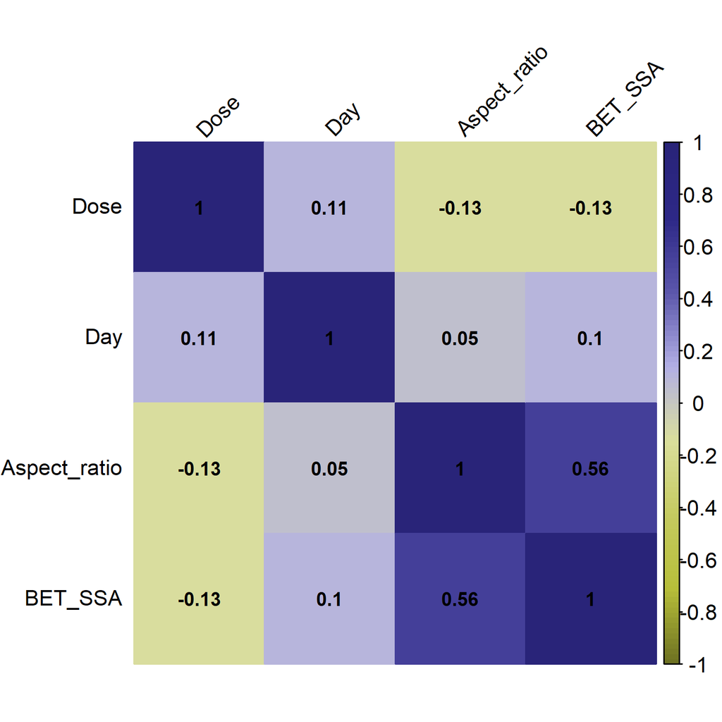

```r
# Save Heatmap to PNG
png("docs/figures/HeatMap.png", width = 1500, height = 1500, units = "px", res = 300)

# Computing the correlation matrix

CorrelationMatrix <- cor(data[, 2:(ncol(data) - 1)], use = "complete.obs")

# Color palette for the plot
col <- colorRampPalette(c("#6e7222","#b8bf3a", "#c6cb61", "#dbdf9c", "#b3b0e5", "#5c57ac", "#2e2988", "#292479"))

# Heatmap
corrplot(CorrelationMatrix,
          method = "color",
          col = col(100),
          tl.col = "black",
          tl.srt = 45,
          addCoef.col = "black",
          number.cex=0.8,
          tl.cex = 0.9,
          cl.cex = 0.9)

invisible(dev.off())
```

### Boxplots

The distribution of the dependent variable is shown across different doses and exposure durations to the nanomaterial. The boxplot highlights the toxicity values, with the median indicated by the thick line within the box. The box boundaries represent the first and third quartiles of the data, while the “whiskers” extend to 1.5 times the interquartile range (IQR) beyond the quartiles. Points beyond this range are identified as outliers.

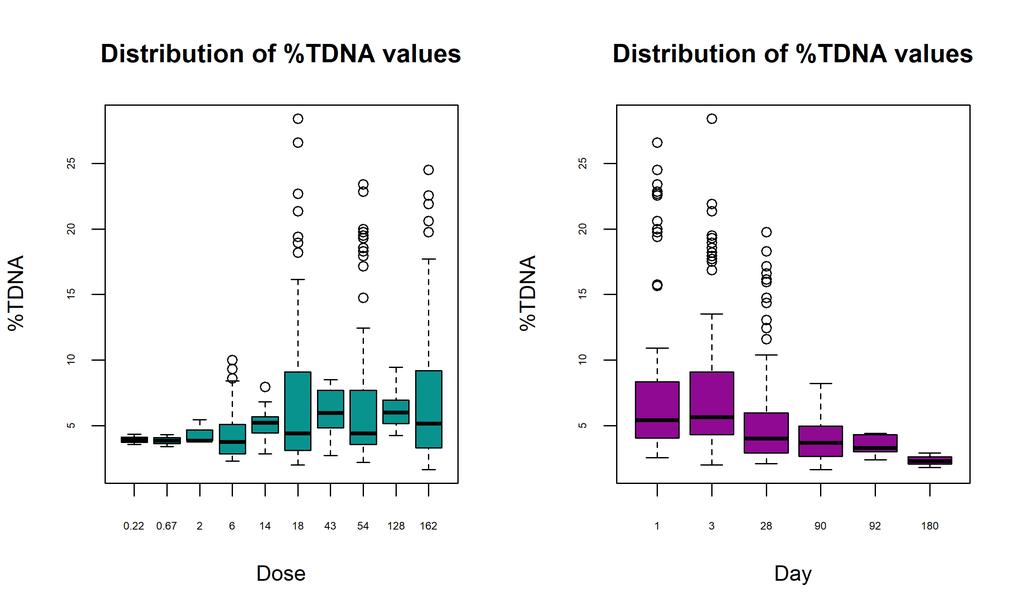

```r
#Save Boxplot to PNG
png("docs/figures/Boxplot.png", width = 2400, height = 1440, units = "px", res = 300)

# Arranging two plots horizontally in a single graphic
par(mfrow = c(1,2))

# Boxplots
boxplot(TDNA~ Dose,
        data = data,
        col = "#09938F",
        xlab = "Dose",
        ylab = "%TDNA",
        main = "Distribution of %TDNA values",
        cex.axis = 0.5,
        cex.lab = 1,
        cex.main = 1.2)
boxplot(TDNA~ Day,
        data = data,
        col = "#8f0993",
        xlab = "Day",
        ylab = "%TDNA",
        main = "Distribution of %TDNA values",
        cex.axis = 0.5,
        cex.lab = 1,
        cex.main = 1.2)

invisible(dev.off())
```